# Flight Performance of US Carriers in All Major US Airport

## by Maria Soccoro Ingco

## Investigation Overview

- The goal of the investigation was to determine the flight performance of carriers, such as the overall on-time arrival rate, typical causes of delays and the busiest months in the year.

## Dataset Overview

- The dataset used for this analysis was taken from [Bureau of Transportation Statistics](https://www.transtats.bts.gov/OT_Delay/OT_DelayCause1.asp?pn=1).

### On-time Arrivals

From 2015-2019, the overall on-time performance was ~80%.

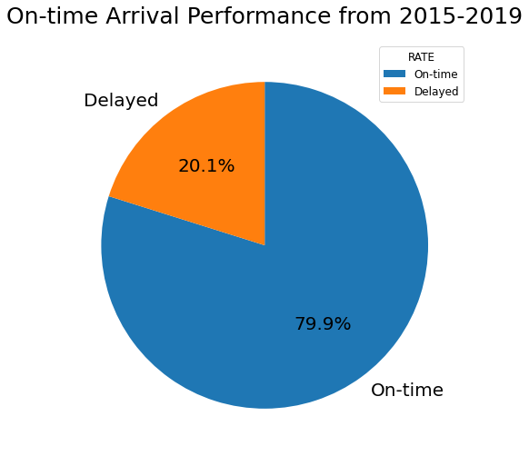

### Causes of Delays

The top reason for delay was due to national aviation system at 32.9%, which according to [Bureau of Transportation Statistics](https://www.transtats.bts.gov/OT_Delay/ot_delaycause1.asp?6B2r=I&20=E) includes weather condition, high volume of flights, and closed runways. Not a far second place was due aircraft arriving late at 31.8%. Capping the top 3 causes of delay was the air carrier delay at 23.4%.

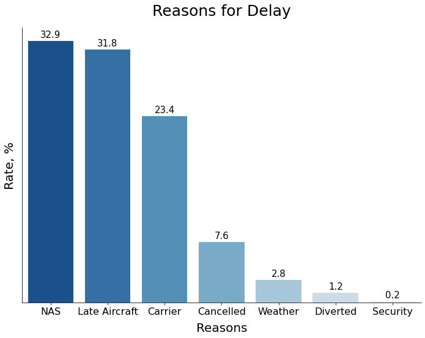

*Note: Cancelled and diverted have no time element.*

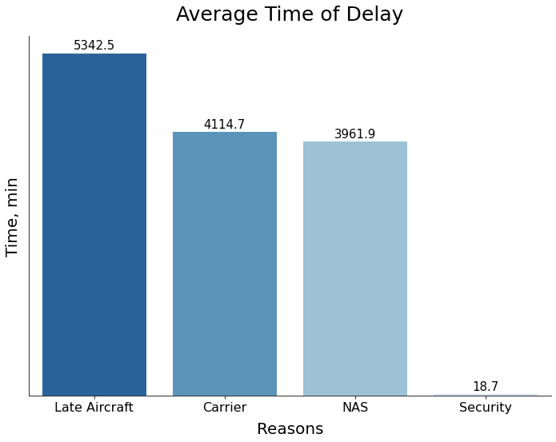

### Arrivals and Delays Relationship

In general, it was observed that higher number of arrivals resulted to higher delays, both in counts and time delay. It was seen that during the months of June to August that the highest number of arrivals and delays and the longest time delays were recorded.

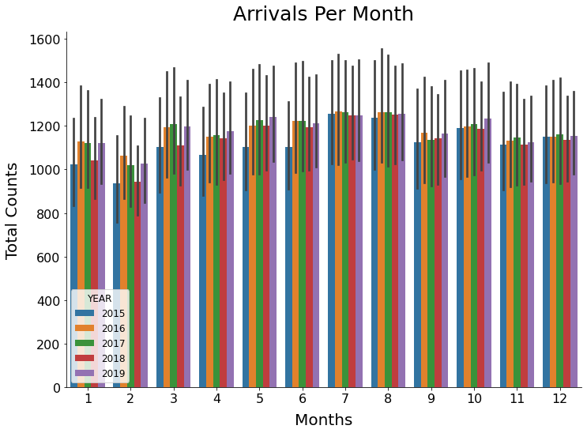

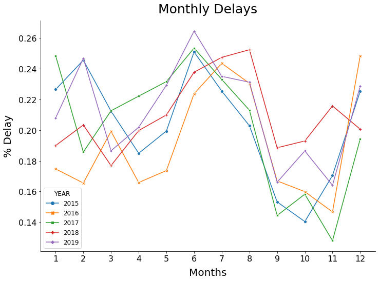

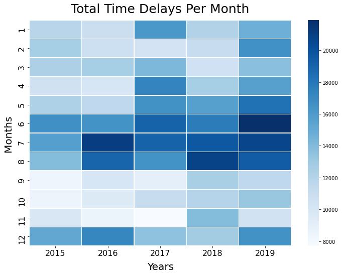